# ESM 204 Assignment 2

Evie Vermeer & Lucas Boyd

4/12/2022

```r
knitr::opts_chunk$set(echo = TRUE, message = FALSE, warning = FALSE)
library(tidyverse)
library(here)
library(janitor)
library(broom)
library(equatiomatic)
library(kableExtra)
```

# California Water Districts

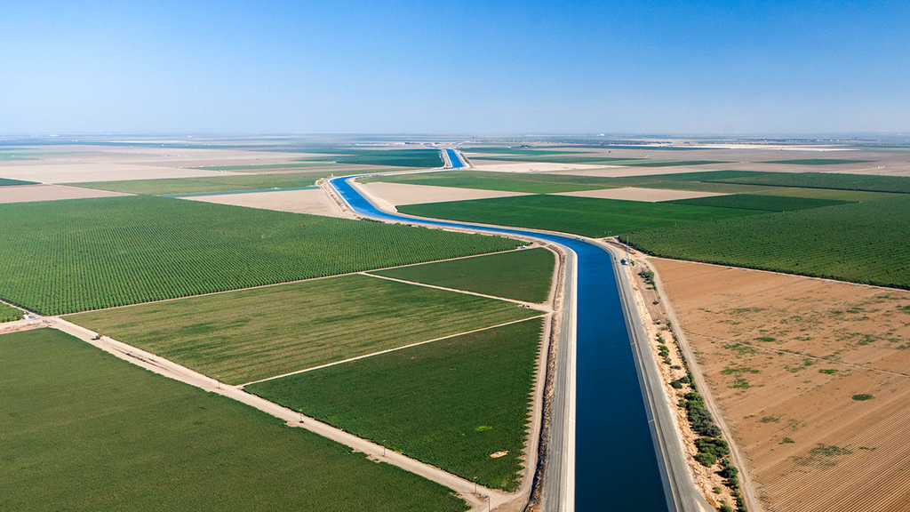

## 1. Marginal Abatement

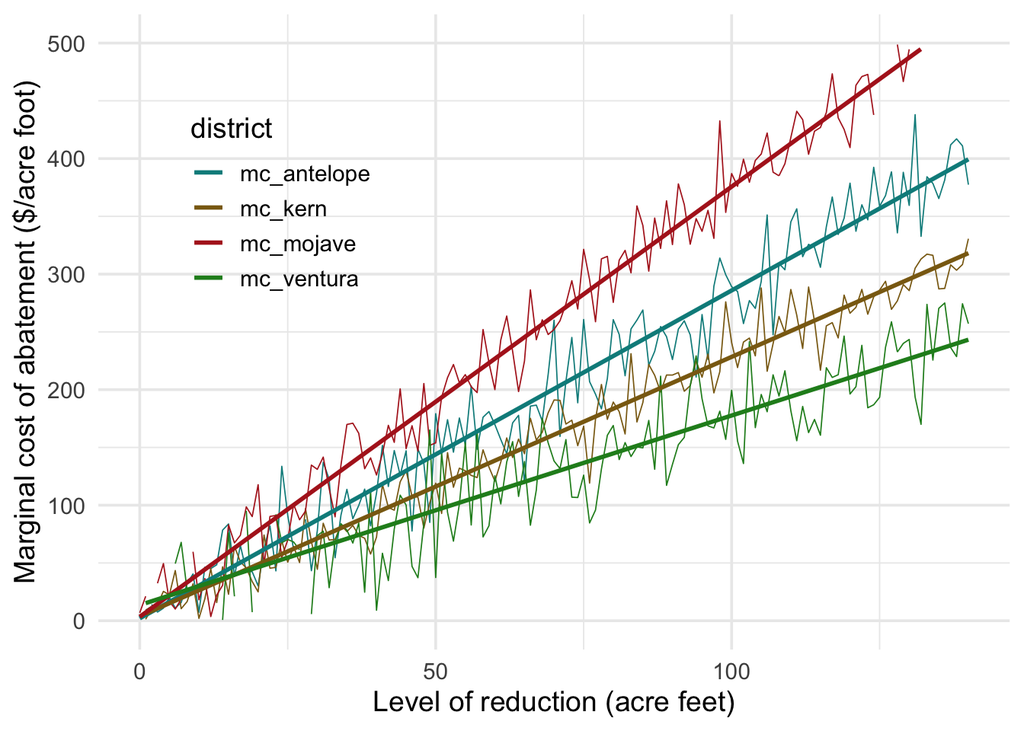

```r
water <- read_csv(here("data", "Water_Districts.csv")) %>%
  clean_names() %>%
  mutate(mc_aggregate = mc_kern + mc_antelope + mc_ventura + mc_mojave)

water_longer <- water %>%
  pivot_longer(cols = c(3:6), names_to = "district", values_to = "mc") %>%
  mutate(county = case_when(
    district == "mc_kern" ~ "Kern",
    district == "mc_antelope" ~ "Antelope",
    district == "mc_ventura" ~ "Ventura",
    district == "mc_mojave" ~ "Mojave",
    district == "mc_aggregate" ~ "Aggregate"
  ))

ggplot(data = water_longer,
       aes(x = reduction, y = mc, color = district)) +
  geom_line(size = 0.3) +
  geom_smooth(se = FALSE, method = "lm") +
  theme_minimal(14) +
  labs (y = "Marginal cost of abatement ($/acre foot)",
        x = "Level of reduction (acre feet)") +
  scale_color_manual(values = c("cyan4", "goldenrod4", "firebrick", "forestgreen", "black")) +
  theme(legend.position = c(0.2, 0.7)) +
  scale_y_continuous(limits = c(0, 500))
```

**Figure 1** shows marginal cost of abatement of water use for each district, thick, straight lines represent a model fit to the data using simple linear regression.

```r
lm_kern <- lm(mc_kern ~ 0 + reduction, data = water)
lm_ventura <- lm(mc_ventura ~ 0 + reduction, data = water)
lm_antelope <- lm(mc_antelope ~ 0 + reduction, data = water)
lm_mojave <- lm(mc_mojave ~ 0 + reduction, data = water)
lm_aggregate <- lm(mc_aggregate ~ 0 + reduction, data = water)
```

### Linear models

Estimating the marginal abatement cost for each district and the aggregate of all districts.

```r
extract_eq(lm_kern, use_coefs = TRUE)
```

$$\operatorname{\widehat{mc\_kern}} = 2.29(\operatorname{reduction})$$

```r
extract_eq(lm_ventura, use_coefs = TRUE)
```

$$\operatorname{\widehat{mc\_ventura}} = 1.78(\operatorname{reduction})$$

```r
extract_eq(lm_antelope, use_coefs = TRUE)
```

$$\operatorname{\widehat{mc\_antelope}} = 2.86(\operatorname{reduction})$$

```r
extract_eq(lm_mojave, use_coefs = TRUE)
```

$$\operatorname{\widehat{mc\_mojave}} = 3.8(\operatorname{reduction})$$

```r
slope_kern <- lm_kern$coefficients[1]
slope_ventura <- lm_ventura$coefficients[1]
slope_antelope <- lm_antelope$coefficients[1]
slope_mojave <- lm_mojave$coefficients[1]
slope_aggregate <- 1/slope_kern + 1/slope_ventura + 1/slope_antelope + 1/slope_mojave
```

## 2. Demand Curves

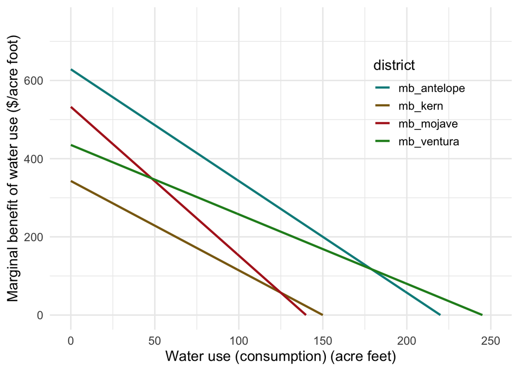

```r
demand_vector <- c(0:250)

use_kern <- 150
use_mojave <- 140
use_antelope <- 220
use_ventura <- 245
use_aggregate <- 755

demand_df <- data.frame(demand_vector) %>%
  mutate(mb_kern = slope_kern*(use_kern - demand_vector)) %>%
  mutate(mb_ventura = slope_ventura*(use_ventura - demand_vector)) %>%
  mutate(mb_mojave = slope_mojave*(use_mojave - demand_vector)) %>%
  mutate(mb_antelope = slope_antelope*(use_antelope - demand_vector)) %>%
  pivot_longer(cols = c(2:5), names_to = "district", values_to = "mb") %>%
  mutate(county = case_when(
    district == "mb_kern" ~ "Kern",
    district == "mb_antelope" ~ "Antelope",
    district == "mb_ventura" ~ "Ventura",
    district == "mb_mojave" ~ "Mojave"
  ))

ggplot(data = demand_df, aes(x = demand_vector, y = mb, color = district)) +
  geom_line(size = 1) +
  theme_minimal(14) +
  scale_y_continuous(limits = c(0, 750)) +
  labs (y = "Marginal benefit of water use ($/acre foot)",
        x = "Water use (consumption) (acre feet)") +
  scale_color_manual(values = c("cyan4", "goldenrod4", "firebrick", "forestgreen")) +
  theme(legend.position = c(0.8, 0.7))
```

**Figure 2** shows marginal willingness to pay for water for each district.

**The Antelope district** is willing to pay the most for the first acre foot of water, at a price of **$628.68**.

## 3. Policy interventions

#### Water use goal = 500 AF (from 755 AF)

### A. Cap without trade

```r
reduction_target <- 500

stringency_a <- 1-(reduction_target/use_aggregate) # calculating the fractional reduction for all districts

use <- c(use_kern, use_mojave, use_antelope, use_ventura, use_aggregate)
district <- c("Kern", "Mojave", "Antelope", "Ventura", "Aggregate")
mca_slope <- c(slope_kern, slope_mojave, slope_antelope, slope_ventura, slope_aggregate)

template_df <- data.frame(district, use, mca_slope) %>%
  filter(district != "Aggregate")

cap_no_trade_3 <- template_df %>%
  filter(district != "Aggregate") %>%
  mutate(water_use_new = (use*(reduction_target/use_aggregate))) %>% # calculating water use after the mandated reduction
  mutate(abatement = use - water_use_new) %>% # calculating the total abatement required by each district
  mutate(total_cost = (abatement*(abatement*mca_slope))/2) %>% # area under the MCA curve to calculate total cost to each district for that level of abatement
  mutate(stringency = stringency_a) %>% # calculating stringency by dividing abatement by initial use
  select(district, abatement, water_use_new, total_cost, stringency)

kable(cap_no_trade_3, digits = 2, col.names =
        c("District", "Abatement (AF)", "Water Use (AF)", "Cost to District (USD)", "Stringency")) %>%
  kable_styling(bootstrap_options = "striped", full_width = FALSE, position = "left")
```

| District | Abatement (AF) | Water Use (AF) | Cost to District (USD) | Stringency |
| --- | --- | --- | --- | --- |
| Kern | 50.66 | 99.34 | 2934.18 | 0.34 |
| Mojave | 47.28 | 92.72 | 4252.62 | 0.34 |
| Antelope | 74.30 | 145.70 | 7888.77 | 0.34 |
| Ventura | 82.75 | 162.25 | 6080.54 | 0.34 |

```r
total_cost_a <- round(sum(cap_no_trade_3$total_cost[1:4]), 0)
```

**Total cost of this policy:** $21156

There are no taxes collected under this policy intervention so **tax revenue is zero**.

### B. Tax on water use

```r
# calculate the necessary tax by solving for
tax <- (755-reduction_target)/slope_aggregate

tax_df_full <- template_df %>%
  mutate(abatement = tax/mca_slope) %>% # calculating abatement by each district by plugging in the tax and solving for quantity abated for each district
  mutate(total_cost_abatement = (abatement*abatement*mca_slope)/2) %>% # calculating total cost by finding the area under the curve for each district at that level of abatement
  mutate(stringency = abatement/use) %>% # calculating stringency by dividing abatement by initial use
  mutate(water_use = use - abatement) %>%
  mutate(total_cost = (water_use*tax) + total_cost_abatement)

tax_df <- tax_df_full %>%
  select(district, abatement, water_use, total_cost, stringency)

kable(tax_df, digits = 2, col.names =
        c("District", "Abatement (AF)", "Water Use (AF)", "Cost to District (USD)", "Stringency")) %>%
  kable_styling(bootstrap_options = "striped", full_width = FALSE, position = "left")
```

| District | Abatement (AF) | Water Use (AF) | Cost to District (USD) | Stringency |
| --- | --- | --- | --- | --- |
| Kern | 69.13 | 80.87 | 18246.11 | 0.46 |
| Mojave | 41.55 | 98.45 | 18845.33 | 0.30 |
| Antelope | 55.31 | 164.69 | 30403.08 | 0.25 |
| Ventura | 89.00 | 156.00 | 31692.46 | 0.36 |

```r
total_cost_b <- round(sum(tax_df$total_cost[1:4]), 0) # calculating the total cost to all districts
tax_rev_b <- round(reduction_target*tax, 0) # calculating tax revenue by multiplying the total water use by the tax
```

**Total cost of this policy:** $99187

**Tax Revenue:** $79033

### C. Cap and trade

```r
cap_and_trade <- template_df %>%
  mutate(water_use_no_trade = (use*(reduction_target/use_aggregate))) %>% # pulling code from (A) to calculate the water use before trading
  mutate(abatement_before_trade = use - water_use_no_trade) %>% # calculating the abatement before trading
  mutate(abatement_after_trade = tax/mca_slope) %>% # calculating abatement by each district by plugging in the tax and solving for quantity abated for each district
  mutate(buy_sell = abatement_before_trade - abatement_after_trade) %>%
  mutate(total_cost_before_trade = (abatement_before_trade*abatement_before_trade*mca_slope)/2) %>% # calculating total cost by finding the area under the curve for each district at that level of abatement
  mutate(total_cost_after_trade = (abatement_after_trade*abatement_after_trade*mca_slope)/2) %>% # calculating total cost of abatement after trading is allowed
  mutate(total_cost = total_cost_after_trade + buy_sell*tax) %>% # addding the revenue generated from buying and selling water rights
  mutate(stringency = abatement_after_trade/use) %>% # calculating stringency by dividing abatement by initial use
  mutate(use_after_trade = use - abatement_after_trade) %>%
  select(district, abatement_after_trade, use_after_trade, total_cost, stringency)

kable(cap_and_trade, digits = 2, col.names =
        c("District", "Abatement (AF)", "Water Use (AF)", "Cost to District (USD)", "Stringency")) %>%
  kable_styling(bootstrap_options = "striped", full_width = FALSE, position = "left")
```

| District | Abatement (AF) | Water Use (AF) | Cost to District (USD) | Stringency |
| --- | --- | --- | --- | --- |
| Kern | 69.13 | 80.87 | 2544.10 | 0.46 |
| Mojave | 41.55 | 98.45 | 4190.12 | 0.30 |
| Antelope | 55.31 | 164.69 | 7373.46 | 0.25 |
| Ventura | 89.00 | 156.00 | 6045.84 | 0.36 |

```r
total_cost_c <- round(sum(cap_and_trade$total_cost[1:4]), 0) # calculating the total cost to all districts
```

**Total cost of this policy:** $20154

There are no taxes collected under this policy intervention so **tax revenue is zero**.

## 4. Drought

#### Water use goal = 300 AF (from 500 AF)

### A. Cap without trade

```r
reduction_target <- 300 # change this number to run for drought

use_aggregate <- 500

stringency_a <- 1-(reduction_target/use_aggregate) # calculating the fractional reduction for all districts

use_original <- c(use_kern, use_mojave, use_antelope, use_ventura)
use <- cap_no_trade_3$water_use_new
district <- c("Kern", "Mojave", "Antelope", "Ventura")
mca_slope <- c(slope_kern, slope_mojave, slope_antelope, slope_ventura)

template_df <- data.frame(district, use, mca_slope, use_original) %>%
  filter(district != "Aggregate")

cap_no_trade <- template_df %>%
  mutate(water_use_new = (use*(reduction_target/use_aggregate))) %>% # calculating water use after the mandated reduction
  mutate(abatement = use - water_use_new) %>% # calculating the total abatement required by each district
  mutate(total_cost = (((cap_no_trade_3$abatement + abatement)*(cap_no_trade_3$abatement + abatement)*mca_slope)/2) - cap_no_trade_3$total_cost)  %>% # area under the MCA curve to calculate total cost to each district for that level of abatement
  mutate(stringency = stringency_a) %>% # calculating stringency by dividing abatement by initial use
  select(district, abatement, water_use_new, total_cost)

kable(cap_no_trade, digits = 2, col.names =
        c("District", "Abatement (AF)", "Water Use (AF)", "Cost to District (USD)")) %>%
  kable_styling(bootstrap_options = "striped", full_width = FALSE, position = "left")
```

| District | Abatement (AF) | Water Use (AF) | Cost to District (USD) |
| --- | --- | --- | --- |
| Kern | 39.74 | 59.60 | 6407.58 |
| Mojave | 37.09 | 55.63 | 9286.77 |
| Antelope | 58.28 | 87.42 | 17227.31 |
| Ventura | 64.90 | 97.35 | 13278.54 |

```r
total_cost_a <- round(sum(cap_no_trade$total_cost[1:4]), 0)
```

**Total cost of this policy:** $46200

There are no taxes collected under this policy intervention so **tax revenue is zero**.

### B. Tax on water use

```r
use <- tax_df$water_use
# calculate the necessary tax by solving for
tax <- (755-reduction_target)/slope_aggregate

tax_df_drought <- template_df %>%
  mutate(former_cost = tax_df_full$total_cost_abatement) %>%
  mutate(abatement = tax/mca_slope) %>% # calculating abatement by each district by plugging in the tax and solving for quantity abated for each district
  mutate(total_cost_abatement = (((abatement)*(abatement)*mca_slope)/2) - former_cost)  %>% # calculating total cost by finding the area under the curve for each district at that level of abatement
  mutate(stringency = abatement/use) %>% # calculating stringency by dividing abatement by initial use
  mutate(water_use = use - (abatement - tax_df$abatement)) %>%
  mutate(abatement = use - water_use) %>%
  mutate(total_cost = (water_use*tax) + total_cost_abatement) %>%
  select(district, abatement, water_use, total_cost)

kable(tax_df_drought, digits = 2, col.names =
        c("District", "Abatement (AF)", "Water Use (AF)", "Cost to District (USD)")) %>%
  kable_styling(bootstrap_options = "striped", full_width = FALSE, position = "left")
```

| District | Abatement (AF) | Water Use (AF) | Cost to District (USD) |
| --- | --- | --- | --- |
| Kern | 54.22 | 45.11 | 24656.19 |
| Mojave | 32.59 | 60.13 | 24129.32 |
| Antelope | 43.38 | 102.31 | 38402.85 |
| Ventura | 69.80 | 92.45 | 41434.70 |

```r
total_cost_b <- round(sum(tax_df_drought$total_cost[1:4]), 0) # calculating the total cost to all districts
tax_rev_b <- round(reduction_target*tax, 0) # calculating tax revenue by multiplying the total water use by the tax
```

**Total cost of this policy:** $128623

**Tax Revenue:** $84612

### C. Cap and trade

```r
cap_and_trade_drought <- template_df %>%
  mutate(water_use_no_trade = (use*(reduction_target/use_aggregate))) %>% # pulling code from (A) to calculate the water use before trading
  mutate(abatement_before_trade = use - water_use_no_trade) %>% # calculating the abatement before trading
  mutate(abatement_after_trade = (tax/mca_slope) - cap_and_trade$abatement_after_trade) %>% # calculating abatement by each district by plugging in the trading price and solving for quantity abated for each district
  mutate(buy_sell = abatement_before_trade - abatement_after_trade) %>%
  mutate(total_cost_before_trade = ((use + abatement_before_trade)*(use + abatement_before_trade)*(mca_slope))/2 - cap_no_trade_3$total_cost) %>% # calculating total cost by finding the area under the curve for each district at that level of abatement
  mutate(total_cost_after_trade = (cap_and_trade$abatement_after_trade + abatement_after_trade)*(cap_and_trade$abatement_after_trade + abatement_after_trade*mca_slope)/2) %>% # calculating total cost of abatement after trading is allowed
  mutate(total_cost = total_cost_after_trade + buy_sell*tax) %>% # adding the revenue generated from buying and selling water rights
  mutate(stringency = abatement_after_trade/use) %>% # calculating stringency by dividing abatement by initial use
  mutate(use_after_trade = use - abatement_after_trade) %>%
  select(district, abatement_after_trade, use_after_trade, total_cost)

kable(cap_and_trade_drought, digits = 2, col.names =
        c("District", "Abatement (AF)", "Water Use (AF)", "Cost to District (USD)")) %>%
  kable_styling(bootstrap_options = "striped", full_width = FALSE, position = "left")
```

| District | Abatement (AF) | Water Use (AF) | Cost to District (USD) |
| --- | --- | --- | --- |
| Kern | 54.22 | 45.11 | 7824.48 |
| Mojave | 32.59 | 60.13 | 7404.32 |
| Antelope | 43.38 | 102.31 | 13048.54 |
| Ventura | 69.80 | 92.45 | 15527.61 |

```r
total_cost_c <- round(sum(cap_and_trade_drought$total_cost[1:4]), 0) # calculating the total cost to all districts
```

**Total cost of this policy:** $43805

There are no taxes collected under this policy intervention so **tax revenue is zero**.

### Policy preferences by district

```r
kern_policy <- round(cap_no_trade_3$total_cost[1] + cap_no_trade$total_cost[1], 0)
mojave_policy <- round(cap_and_trade$total_cost[2] + cap_and_trade_drought$total_cost[2], 0)
antelope_policy <- round(cap_and_trade$total_cost[3] + cap_and_trade_drought$total_cost[3], 0)
ventura_policy <- round(cap_no_trade_3$total_cost[4] + cap_no_trade$total_cost[4], 0)
```

The policies that minimize total cost to each district are as follows:

- **Kern** prefers **cap without trade** ($9342)
- **Mojave** prefers a **cap and trade** ($11594)
- **Antelope** prefers a **cap and trade** ($20422)
- **Ventura** prefers **cap without trade** ($19359)

#### Allocation Considerations

Since rights are rarely allocated in a perfectly efficient manner, some districts would prefer cap and trade above a tax on water use or cap without trade, which are more prescriptive solutions that don’t allow for adjustments to efficiency. Reducing barriers to transaction and allowing for trading will help market shifts towards each consumer satisfying the equal marginal principle, where over-allocated consumers may realize benefits from selling to under-allocated consumers.